# Görsel Programlama

## Çıktı Araçları

Çıktı araçları kullanıcıya bilgi göstermek için kullanılır.

- ADD : Aracı ekler.
- GET : Aracın mevcut durumunu ya da içeriğini alır, kaydeder.
- SET : Aracın içindekini değiştirir.

Genel olarak önce bu üçünden biri yazılır hemen ardında ise ilgili aracın adı gelir.

### Etiket

Etiket eklemek için gui() sınıfına ait **addLabel()** metodu kullanılır.

[figure not shown]

image

```python
from appJar import gui
p = gui()
p.setSize(300,200)

#'Merhaba' başlıklı bir metin ekle.
p.addLabel('Merhaba')

p.go()
```

### Çok Satırlı Etiket

Çok satırlı metin çıktı kutusu eklemek için gui() sınıfına ait **addMessage()** metodu kullanılır.

[figure not shown]

image

```python
from appJar import gui
p = gui()
p.setSize(400,300)

# 'Pynar' başlıklı ve üzerinde uzun bir metin yazılı bir
#çok satırlı metin oluştur.
p.addMessage('Pynar', '''PyNar, Türkiye’nin ilk Tamamen
Türkçe arayüze sahip Python kod editörüdür.

PyNar Editörü TÜBİTAK Açık Kaynak Yazılımlar Çağrı Programı
“1003 Türkçe Arayüz ve Destek Sistemleri” çağrısı
kapsamında geliştirilmektedir.

PyNar, bir kod editörü olmasının yanı sıra Entegre bir
Chatbot’a sahiptir. Chatbot, makine öğrenmesi destekli olup
kullanıcının hatalarında düzeltme önerileri sunmaktadır.''')

p.go()
```

## Karma Örnek

Buton ve Metin kutusu kullanarak bir etiketi değiştiren örnek uygulamalı bir kod.

[figure not shown]

image

```python
def press():#Buton her tıklandığında çağrılacak olan fonksiyon
    #Metinkutusu isimli metin kutusundaki metni 'yazi' değişkenine aktar
    yazi = p.getEntry('Metinkutusu')

    #'Etiket' başlıklı etiketteki metni 'yazi' değişkenindeki yazı olarak ayarla
    p.setLabel('Etiket', yazi)

from appJar import gui

#Pencereyi oluştur
p = gui()

#Pencerenin en,boy uzunluklarını 300,200 olarak ayarla
p.setSize(300,200)

#Pencerenin başlığını 'Birleşik Örnek' olarak ayarla
p.setTitle('Birleşik Örnek')

#Pencereye 'Etiket' başlıklı bir etiket ekle
p.addLabel('Etiket')

#Pencereye 'Metinkutusu' başlıklı bir metin kutusu ekle
p.addEntry('Metinkutusu')

#Pencereye 'Tıkla' başlıklı bir buton ekle,
#ve bu buton her tıklandığında 'press' fonksiyonunu çağır
p.addButton('Tıkla', press)

#Pencereyi başlat
p.go()
```

Metin kutusuna girilen metin butona tıklandığında etiketi değiştirecektir.

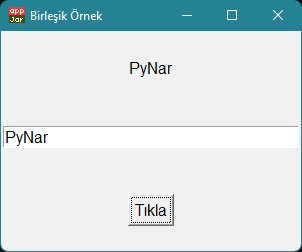

image

## Açılır Pencereler

Açılır Pencereler bir etkileşim sonucu ya da bir bilgiyi sunmak için açılan fazladan küçük pencerelerdir.

### Mesaj Penceresi

Mesaj penceresi eklemek için gui() sınıfına ait **infoBox()** metodu kullanılır.

```python
from appJar import gui

def press():#Butona tıklandığı zaman çağrılacak fonksiyon
    #'Pencere' başlıklı ve içinde
    #'Merhaba!' yazan bir açılır pencere göster
    p.infoBox('Pencere', 'Merhaba!', parent=None)

#Pencereyi oluştur
p = gui()

#Pencerenin en,boy uzunluklarını 300,200 olarak ayarla
p.setSize(300,200)

#'Buton' başlıklı bir buton ekle ve
#Bu butona her tıklandığında 'press' fonksiyonunu çalıştır
p.addButton('Buton', press)

#Pencereyi başlat
p.go()
```

image

Oluşturulan pencere butona tıklandığında ortaya çıkacaktır.

[figure not shown]

image

### Hata Penceresi

Hata penceresi eklemek için gui() sınıfına ait **errorBox()** metodu kullanılır.

```python
from appJar import gui

def press():#Butona tıklandığı zaman çağrılacak fon5ksiyon
    #'Hata' başlıklı ve içinde
    #'Hata!' yazan bir açılır pencere göster
    p.errorBox('Hata', 'Hata!', parent=None)

#Pencereyi oluştur
p = gui()

#Pencerenin en,boy uzunluklarını 300,200 olarak ayarla
p.setSize(300,200)

#'Buton' başlıklı bir buton ekle ve
#Bu butona her tıklandığında 'press' fonksiyonunu çalıştır
p.addButton('Buton', press)

#Pencereyi başlat
p.go()
```

image

[figure not shown]

image

### Uyarı Penceresi

Uyarı penceresi eklemek için gui() sınıfına ait **warningBox()** metodu kullanılır.

```python
from appJar import gui

def press():#Butona tıklandığı zaman çağrılacak fonksiyon
    #'Uyarı' başlıklı ve içinde
    #'Uyarı!' yazan bir açılır pencere göster
    p.warningBox('Uyarı', 'Uyarı!', parent=None)

#Pencereyi oluştur
p = gui()

#Pencerenin en,boy uzunluklarını 300,200 olarak ayarla
p.setSize(300,200)

#'Buton' başlıklı bir buton ekle ve
#Bu butona her tıklandığında 'press' fonksiyonunu çalıştır
p.addButton('Buton', press)

#Pencereyi başlat
p.go()
```

image

[figure not shown]

image

### Soru Penceresi

Soru penceresi eklemek için gui() sınıfına ait **questionBox()** metodu kullanılır. **questionBox()** metodu seçim yapıldıktan sonra bir boolean değeri döndürür.

```python
from appJar import gui

def press():#Butona tıklandığı zaman çağrılacak fonksiyon
    #'Soru' başlıklı ve içinde
    #'Mesaj' yazan bir açılır pencere göster
    #Ve basılan butonu bool değişkenine aktar(Evet->True, Hayır->False)
    bool = p.questionBox('Soru', 'Mesaj', parent=None)
    #bool değişkenini yazdır
    print(bool)

#Pencereyi oluştur
p = gui()

#Pencerenin en,boy uzunluklarını 300,200 olarak ayarla
p.setSize(300,200)

#'Buton' başlıklı bir buton ekle ve
#Bu butona her tıklandığında 'press' fonksiyonunu çalıştır
p.addButton('Buton', press)

#Pencereyi başlat
p.go()
```

image

[figure not shown]

image

image

### Onay Penceresi

Onay penceresi eklemek için gui() sınıfına ait **okBox()** metodu kullanılır. **okBox()** metodu seçim yapıldıktan sonra bir boolean değeri döndürür.

```python
from appJar import gui

def press():#Butona tıklandığı zaman çağrılacak fonksiyon
    #'Onay' başlıklı ve içinde
    #'Mesaj' yazan bir açılır pencere göster
    #Ve basılan butonu bool değişkenine aktar(Tamam->True, İptal->False)
    bool = p.okBox('Onay', 'Mesaj', parent=None)
    #bool değişkenini yazdır
    print(bool)

#Pencereyi oluştur
p = gui()

#Pencerenin en,boy uzunluklarını 300,200 olarak ayarla
p.setSize(300,200)

#'Buton' başlıklı bir buton ekle ve
#Bu butona her tıklandığında 'press' fonksiyonunu çalıştır
p.addButton('Buton', press)

#Pencereyi başlat
p.go()
```

image

[figure not shown]

image

image

### Yeniden Dene Penceresi

Yeniden Dene penceresi eklemek için gui() sınıfına ait **retryBox()** metodu kullanılır. **retryBox()** metodu seçim yapıldıktan sonra bir boolean değeri döndürür.

```python
from appJar import gui

def press():#Butona tıklandığı zaman çağrılacak fonksiyon
    #'Yeniden dene' başlıklı ve içinde
    #'Mesaj' yazan bir açılır pencere göster
    #Ve basılan butonu bool değişkenine aktar(Yeniden dene->True, İptal->False)
    bool = p.retryBox('Yeniden dene', 'Mesaj', parent=None)
    #bool değişkenini yazdır
    print(bool)

#Pencereyi oluştur
p = gui()

#Pencerenin en,boy uzunluklarını 300,200 olarak ayarla
p.setSize(300,200)

#'Buton' başlıklı bir buton ekle ve
#Bu butona her tıklandığında 'press' fonksiyonunu çalıştır
p.addButton('Buton', press)

#Pencereyi başlat
p.go()
```

image

[figure not shown]

image

image

### Metin Kutusu Penceresi

Metin Kutusu penceresi eklemek için gui() sınıfına ait **stringBox()** metodu kullanılır. **stringBox()** metodu içine yazılan metni string olarak döndürür.

```python
from appJar import gui

def press():#Butona tıklandığı zaman çağrılacak fonksiyon
    #Metin penceresi başlıklı ve içinde
    #'Mesaj' yazan bir açılır pencere göster
    #Ve pencereye yazılan metni 'metin' değişkenine aktar
    metin = p.stringBox('Metin penceresi', 'Mesaj', parent=None)
    #metin değişkenini yazdır
    print(metin)

#Pencereyi oluştur
p = gui()

#Pencerenin en,boy uzunluklarını 300,200 olarak ayarla
p.setSize(300,200)

#'Buton' başlıklı bir buton ekle ve
#Bu butona her tıklandığında 'press' fonksiyonunu çalıştır
p.addButton('Buton', press)

#Pencereyi başlat
p.go()
```

image

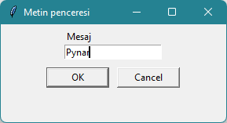

image

Metin kutusunun içine Pynar yazıp onayladıktan sonra alınan çıktı.

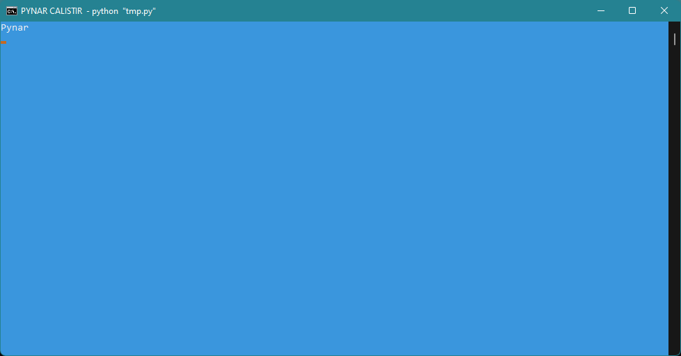

image

### Sayı Kutusu Penceresi

Sayı Kutusu penceresi eklemek için gui() sınıfına ait **integerBox()** metodu kullanılır. **integerBox()** metodu içine yazılan değeri integer olarak döndürür. Eğer mesaj kutusuna tam sayı bir değer yazılmazsa hata verecektir.

```python
from appJar import gui

def press():#Butona tıklandığı zaman çağrılacak fonksiyon
    #Sayı penceresi başlıklı ve içinde
    #'Mesaj' yazan bir açılır pencere göster
    #Ve pencereye yazılan sayıyı 'sayi' değişkenine aktar
    sayi = p.integerBox('Sayı penceresi', 'Mesaj', parent=None)
    #metin değişkenini yazdır
    print(sayi)

#Pencereyi oluştur
p = gui()

#Pencerenin en,boy uzunluklarını 300,200 olarak ayarla
p.setSize(300,200)

#'Buton' başlıklı bir buton ekle ve
#Bu butona her tıklandığında 'press' fonksiyonunu çalıştır
p.addButton('Buton', press)

#Pencereyi başlat
p.go()
```

image

image

Sayı kutusunun içine 123 yazıp onayladıktan sonra alınan çıktı.

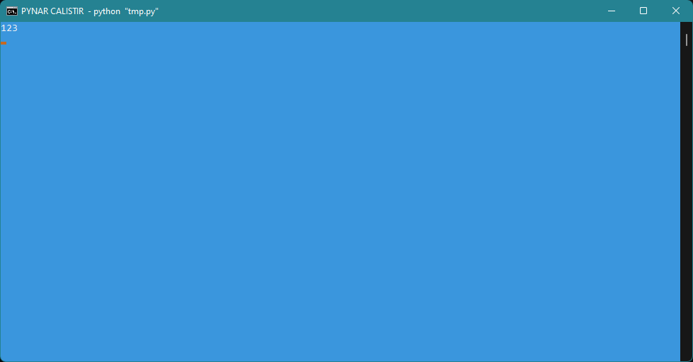

image

Eğer bir metin yazılırsa aşağıdaki gibi hata verecektir.

image

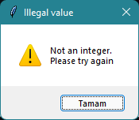

image

### Ondalıklı Sayı Kutusu Penceresi

Ondalıklı Sayı Kutusu penceresi eklemek için gui() sınıfına ait **floatBox()** metodu kullanılır. **floatBox()** metodu içine yazılan değeri float olarak döndürür.

```python
from appJar import gui

def press():#Butona tıklandığı zaman çağrılacak fonksiyon
    #Sayı penceresi başlıklı ve içinde
    #'Mesaj' yazan bir açılır pencere göster
    #Ve pencereye yazılan sayıyı 'sayi' değişkenine aktar
    sayi = p.floatBox('Sayı penceresi', 'Mesaj', parent=None)
    #metin değişkenini yazdır
    print(sayi)

#Pencereyi oluştur
p = gui()

#Pencerenin en,boy uzunluklarını 300,200 olarak ayarla
p.setSize(300,200)

#'Buton' başlıklı bir buton ekle ve
#Bu butona her tıklandığında 'press' fonksiyonunu çalıştır
p.addButton('Buton', press)

#Pencereyi başlat
p.go()
```

image

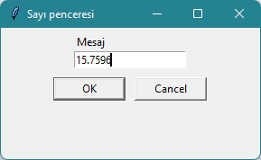

image

Sayı kutusunun içine 15.7596 yazıp onayladıktan sonra alınan çıktı.

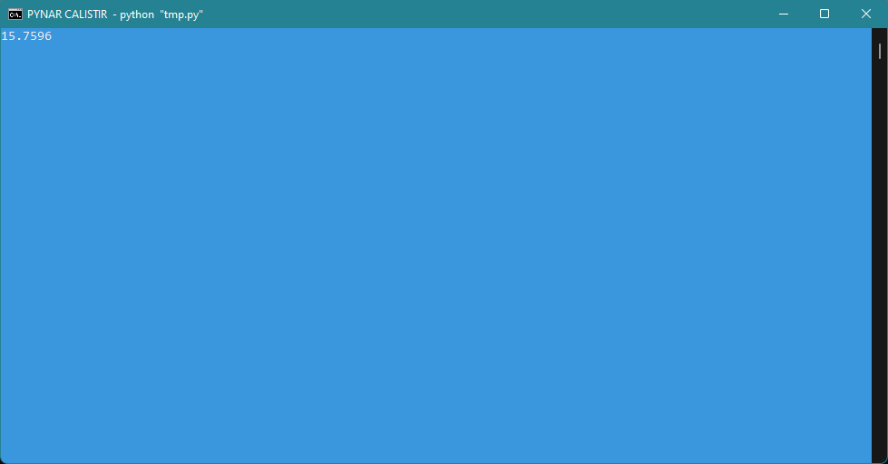

image